# Mushroom Classification Machine Learning - Neural Models

Kiara Zepeda

Dataset Overview:

- Kaggle Data Source (https://www.kaggle.com/datasets/maysee/mushrooms-classification-common-genuss-images/data)
- Contains nine folders with 300-1500 images each, almost 2 GB of storage.
- Images of most common Northern European mushroom genuses

The Objective

- Accurately classify mushrooms into their respective genus.

```python
import zipfile
import os
import shutil
import matplotlib.pyplot as plt
import seaborn as sns
```

```python
# To fix "Image File is truncated" error during training
from PIL import ImageFile
ImageFile.LOAD_TRUNCATED_IMAGES = True
```

There were too many images, I had to upload the data as a zip

```python
zip_file_path = 'mushroom.zip'
```

```python
extracted_folder = 'extracted_data'

# Check if folder exists, create if not
if not os.path.exists(extracted_folder):
    os.makedirs(extracted_folder)

# Extract the contents of the zip file
with zipfile.ZipFile(zip_file_path, 'r') as zip_ref:
    zip_ref.extractall(extracted_folder)

print(f"ZIP file extracted to {extracted_folder}")
```

```
ZIP file extracted to extracted_data
```

```python
extracted_files = os.listdir(extracted_folder)
print(extracted_files)
```

```
['Mushrooms', 'mushrooms']
```

```python
# Checking the structure of the folders
mushrooms_folder = os.path.join(extracted_folder, 'Mushrooms')
mushrooms_folder_contents = os.listdir(mushrooms_folder)
print(f"Contents of 'Mushrooms' folder: {mushrooms_folder_contents}")

mushrooms_lowercase_folder = os.path.join(extracted_folder, 'mushrooms')
mushrooms_lowercase_folder_contents = os.listdir(mushrooms_lowercase_folder)
print(f"Contents of 'mushrooms' folder: {mushrooms_lowercase_folder_contents}")
```

```
Contents of 'Mushrooms' folder: ['Hygrocybe', 'Lactarius', 'Suillus', 'Agaricus', 'Russula', 'Boletus', 'Entoloma', 'Amanita', 'Cortinarius']
Contents of 'mushrooms' folder: ['Mushrooms']
```

```python
import os

# Define the root directory where the mushroom folders are located
root_dir = 'extracted_data/Mushrooms'

# Loop through each subfolder in the root directory
for folder in os.listdir(root_dir):
    folder_path = os.path.join(root_dir, folder)

    # Check if it's a directory
    if os.path.isdir(folder_path):
        # Count the number of image files in this folder
        image_count = 0
        for file in os.listdir(folder_path):
            # Check if the file is an image (based on file extension)
            if file.endswith(('.jpg', '.jpeg', '.png', '.gif', '.bmp')):
                image_count += 1

        # Print the folder name and the count of images in it
        print(f'{folder}: {image_count} images')
```

```
Hygrocybe: 316 images
Lactarius: 1563 images
Suillus: 311 images
Agaricus: 353 images
Russula: 1148 images
Boletus: 1073 images
Entoloma: 364 images
Amanita: 750 images
Cortinarius: 836 images
```

```python
import random

root_dir = 'extracted_data/Mushrooms'
unwanted_genuses = ['Suillus', 'Hygrocybe', 'Agaricus', 'Entoloma']

# Define the path for the unified folder
unified_folder = 'unified_folder'

# Create the unified folder if it doesn't exist
os.makedirs(unified_folder, exist_ok=True)

remaining_genuses = []

# Loop through each subfolder (genus) in the root directory
for genus in os.listdir(root_dir):
    genus_path = os.path.join(root_dir, genus)

    # Skip the unwanted genuses
    if genus in unwanted_genuses or not os.path.isdir(genus_path):
        continue

    # Add to the remaining genus list
    remaining_genuses.append(genus)

# Ensure there are exactly 5 remaining genus
if len(remaining_genuses) != 5:
    print("ERROR: There should be exactly 5 remaining genera.")
else:
    print(f"Remaining genera: {remaining_genuses}")

# Process each remaining genus
for genus in remaining_genuses:
    genus_path = os.path.join(root_dir, genus)
    genus_images = []

    # Get a list of image files in the genus folder
    for file in os.listdir(genus_path):
        if file.endswith(('.jpg', '.jpeg', '.png', '.gif', '.bmp')):
            genus_images.append(os.path.join(genus_path, file))

    # Randomly select 500 images (or all if there are fewer than 500)
    random.shuffle(genus_images)
    selected_images = genus_images[:500]

    # Create a folder for this genus in the unified folder
    genus_folder = os.path.join(unified_folder, genus)
    os.makedirs(genus_folder, exist_ok=True)

    # Copy the selected images to the genus folder in the unified folder
    for i, image_path in enumerate(selected_images):
        destination = os.path.join(genus_folder, f'image_{i+1}.jpg')
        shutil.copy(image_path, destination)

    print(f"Successfully copied 500 images for genus: {genus}")

print(f"Finished processing all genera. 500 random images have been copied to each genus folder.")
```

```
Remaining genera: ['Lactarius', 'Russula', 'Boletus', 'Amanita', 'Cortinarius']
Successfully copied 500 images for genus: Lactarius
Successfully copied 500 images for genus: Russula
Successfully copied 500 images for genus: Boletus
Successfully copied 500 images for genus: Amanita
Successfully copied 500 images for genus: Cortinarius
Finished processing all genera. 500 random images have been copied to each genus folder.
```

Now, the images are in the correct folder and are sorted. Let's do some EDA.

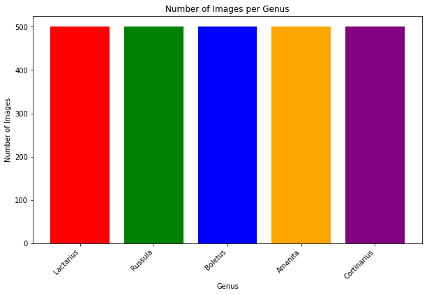

```python
# Path to the unified folder
unified_folder = 'unified_folder'

# List to store the number of images per genus
genus_image_counts = {}

# Loop through the genus folders and count the images
for genus in os.listdir(unified_folder):
    genus_path = os.path.join(unified_folder, genus)

    if os.path.isdir(genus_path):
        image_count = len([f for f in os.listdir(genus_path) if f.endswith(('.jpg', '.jpeg', '.png', '.gif', '.bmp'))])
        genus_image_counts[genus] = image_count

colors = ['red', 'green', 'blue', 'orange', 'purple']

plt.figure(figsize=(10, 6))
plt.bar(genus_image_counts.keys(), genus_image_counts.values(), color=colors[:len(genus_image_counts)])
plt.title('Number of Images per Genus')
plt.xlabel('Genus')
plt.ylabel('Number of Images')
plt.xticks(rotation=45, ha='right')
plt.show()
```